# U1. El comercio y las finanzas internacionales. Patrones, tendencias y evidencias.

Comercio y Finanzas Internacionales

Sebastian Freille

Universidad Nacional de Córdoba

# ¿Por qué estudiar economía internacional?

## Razones y motivaciones

- Los países y estados pueden (y lo hacen) **restringir el movimiento internacional de bienes/servicios y de factores productivos**
- Los movimientos internacionales de factores de producción (inmigración, IED) son frecuentemente más severamente restringidos (en relación al comercio en bienes y servicios)
  - …restricciones más severas casi siempre son hacia el trabajo/inmigración [cfr. situación actual en UK]
- El tema es esencialmente empírico -averiguar cuáles son las fuerzas dominantes

## Razones y motivaciones (cont.)

- Las **tecnologías de producción no fluyen con facilidad a través de las fronteras**
  - Diferencias muy grandes en las tecnologías de producción entre países –no sólo diferencias en la disponibilidad física de factores productivos
  - El uso de ciertas tecnologías está atado al capital humano
    - …que no puede ser transferido entre países
  - Instituciones tienen impacto en la efectividad de la tecnologías
    - Infraestructura de transporte y comunicación
    - Sistema legal
    - Instituciones del mercado de trabajo

## Razones y motivaciones (cont.)

- Alternativamente, muchos países permiten e incentivan el comercio interno dentro de fronteras nacionales
  - Constitución de US tiene cláusula de comercio interestatal
    - Regula el movimiento de toda forma de personas, bienes y servicios
    - …como también transporte y comunicación entre estados
- Similar en Argentina $\longrightarrow$ CN en artículos 10 y 11 explicitan que es libre la circulación de bienes y servicios de producción nacional y de todo lo que ya hubiera entrado por aduanas externas
  - …además serán libres de derechos y aranceles

## Comercio: nacional vs internacional

- ¿Por qué entonces el comercio internacional es tan diferente del comercio nacional?
  - En primer lugar, factores de producción y tecnologías de producción son en general específicos de los países
  - Los países tienen potestad para restringir el comercio internacional
  - Porque muchos políticos se oponen al comercio internacional
  - Porque muchos consumidores (votantes) se oponen al comercio internacional

## Políticos y comercio

[figure not shown]

## Políticos y comercio (cont.)

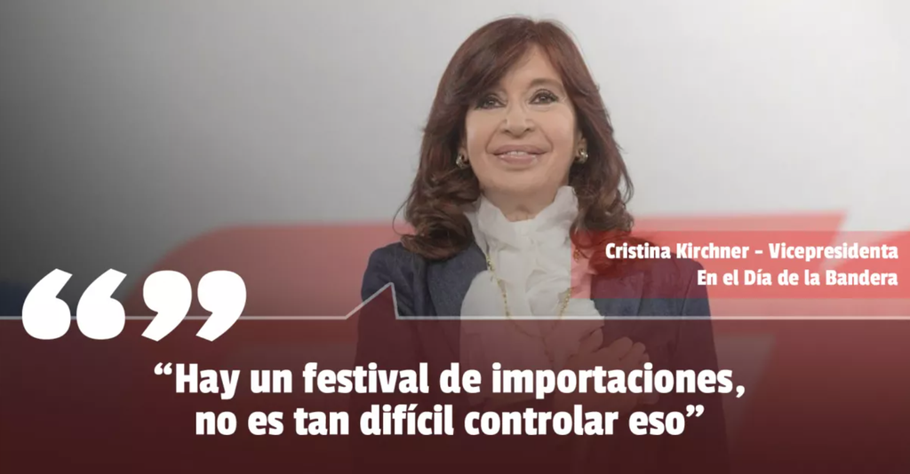

## Políticos y comercio (cont.)

[figure not shown]

## Políticos y comercio (cont.)

[figure not shown]

## Políticos y comercio (cont.)

- Dado que los efectos de la política comercial son frecuentemente estudiados a nivel teórico…
  - y también en ese gran laboratorio de ensayos que es la historia económica

> Seguramente los políticos han aprendido…¿no?
- sobre todo acerca de efectos económicos negativos

## Políticos y comercio (cont.)

[figure not shown]

## Políticos y comercio (cont.)

[figure not shown]

## Políticos y comercio (cont.)

[figure not shown]

## Preferencias: individuos:

- Preferencias individuales ante el comercio internacional no siempre informadas
  - Individuos no tienen por qué conocer cómo afecta el comercio internacional a la economía tanto en lo macro como micro
- Aún si conocieran perfectamente todos los efectos, hay problemas
  - Individuos tienen diferentes roles
    - Productores de bienes transables y no transables
    - Consumidores de bienes transables y no transables
    - Trabajadores
- Opiniones pueden ser segadas en función de contenido informativo

## Preferencias: individuos (cont.)

[figure not shown]

## Preferencias: individuos (cont.)

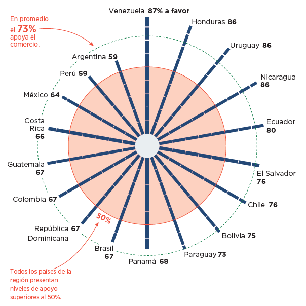

## Preferencias: individuos (cont.)

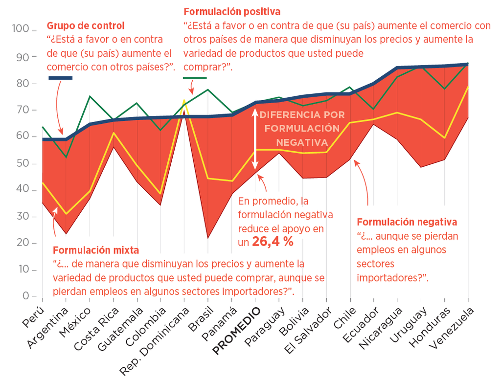

## Pero los economistas…

- Están mayoritariamente a favor del libre comercio –lo cual significa mucho a la luz de las significativas diferencias entre los economistas
  - Tienden a coincidir en que **en promedio** los ciudadanos de EEUU han tenido mejor bienestar con el NAFTA que sin el mismo
  - En general tienden a ponderar los beneficios del comercio a largo plazo al recomendar eliminar el proteccionismo
- Sin embargo $\longrightarrow$ debate intenso sobre efectos distributivos asociados al libre comercio

## …tienden a estar de acuerdo

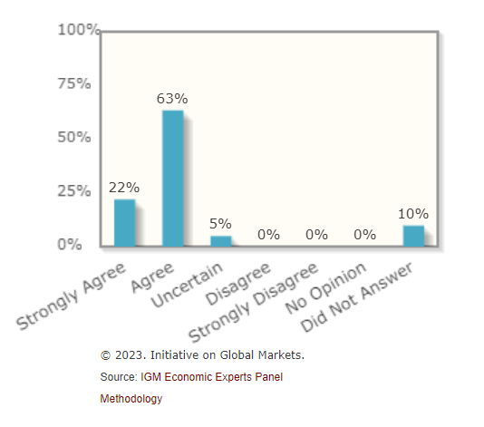

## Estudio de la economía internacional

- Existen dos grandes ramas de la economía internacional
  - comercio internacional –énfasis en **transacciones reales**
    - conficto EEUU-UE en torno a los subsidios a las X agrícolas de la UE
  - finanzas internacionales –énfasis en **aspectos monetarios** de la economía internacional
    - controversia sobre si el tipo de cambio debe flotar libremente o debe ser administrado –“fear to float”
- Materia: comercio internacional será cubierto en las primeras 5 (cinco) unidades mientras que finanzas internacionales será el tema de las unidades 6 a 9.

# Globalización

## El mundo global

> “¡Qué extraordinario episodio del progreso económico del hombre llegó a su fin en agosto de 1914!…Los habitantes de Londres podían pedir por teléfono, mientras se tomaban el té de la mañana en la cama, productos de todo el mundo, en las cantidades que más gustasen y esperar que fueran prontamente entregados a la puerta de su casa”

**[John Maynard Keynes, *Las Consecuencias Económicas de la Paz* (1919)]**

## Globalización: naturaleza

- “Incremento en las transacciones internacionales en los mercados de bienes, servicios and factores” [Deardorff and Stern]
- Crecimiento y alcance expandido de instituciones y organizaciones internacionales
  - Corporaciones multinacionales
  - Instituciones interancionales: ONU, Banco Mundial, FMI, OMC

## Globalización: medición

- Varias medidas posibles
  - **Flujos comerciales:** exportaciones (X) e importaciones (M) de bienes y servicios
  - **Comercio de servicios:** transporte, telecomunicaciones, consultoría, IT, call center
  - **Propiedad de activos extranjeros**
  - **Inmigración**
  - **Convergencia de precios:** posibilidad de comercio puede tener importantes efectos

## M1: Flujos comerciales

[figure not shown]

## M1: Flujos comerciales (cont.)

[figure not shown]

## M2: Exportaciones de servicios

[figure not shown]

## M2: Exportaciones de servicios (cont.)

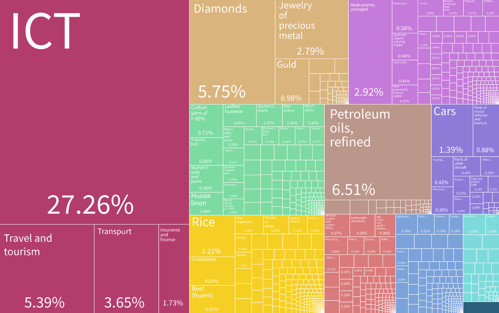

India

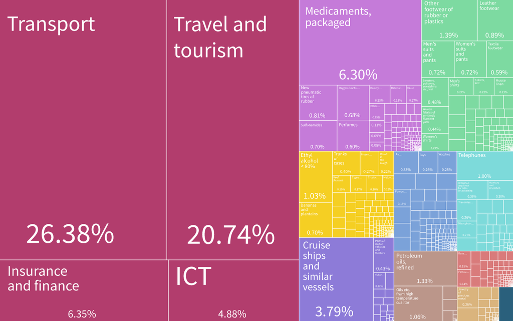

Panamá

## M3: Activos extranjeros

[figure not shown]

## M3: Activos extranjeros

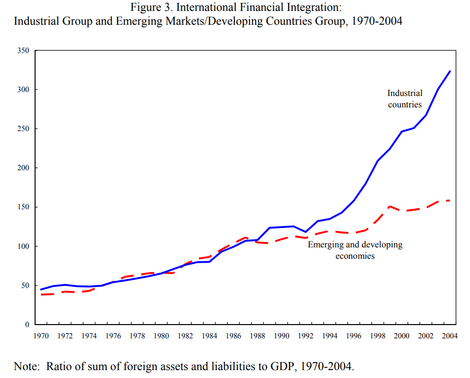

## M4: Migración internacional

[figure not shown]

## M5: Converencia de precios

- Caída en costos de transporte en siglo XIX llevaron a mucha mayor convergencia de precios incluso considerando desde la 2GM
  - Precios de granos en Chicago y Liverpool
    - 60% de diferencia en 1870 a 15% de diferencia en 1912!
- Lo mismo aplica para la convergencia de salarios
  - Principal fenómeno de convergencia en salarios reales mucho mayor en siglo XIX que en 2GM

# Causas de la globalización

## Causas de la globalización

- Siglo XIX $\longrightarrow$ innovación tecnológica trae aparejado disminuiciones en los costos de transporte y comunicación
- Disminución y quita de tarifas y aranceles $\longrightarrow$ advenimiento de GATT y OMC

## Causas de la globalización (cont.)

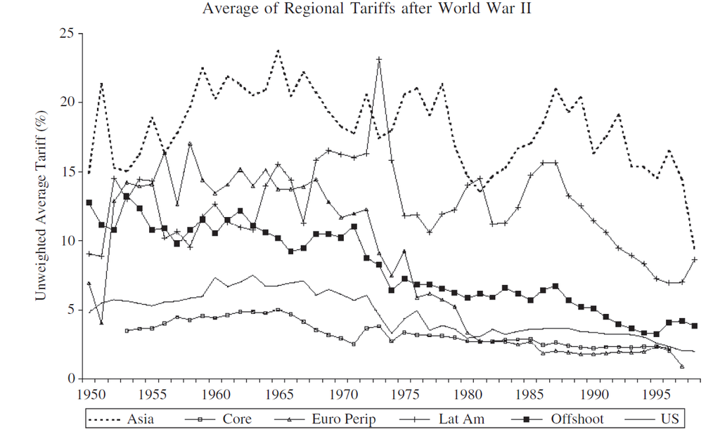

Tarifas desde la 2GM - Países seleccionados

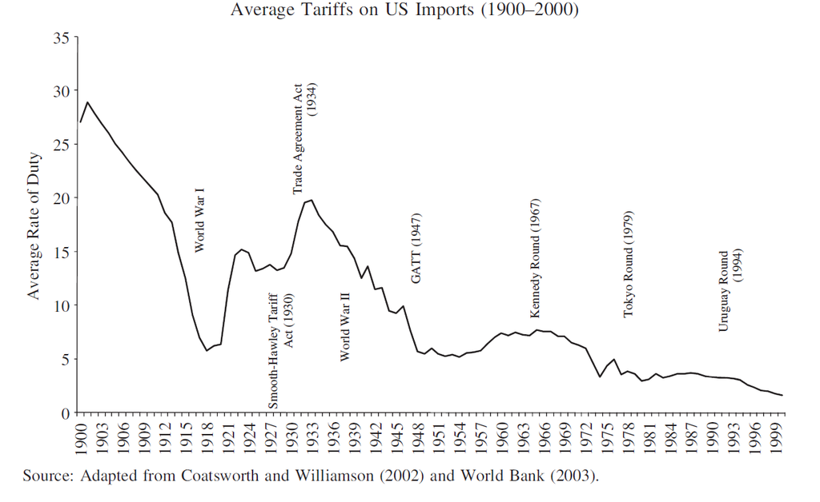

Tarifas de EEEUU desde 1900

## Causas de la globalización (cont.)

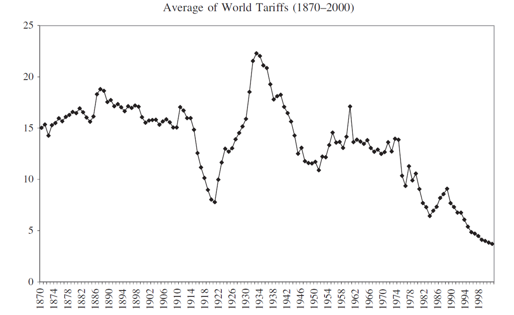

# Patrones de comercio

## ¿Quién comercia con quién?

> Una de las explicaciones más robustas y tradicionales de los patrones de comercio entre países es la dada a través del **modelo de gravedad** del comercio mundial. El nombre se debe a la analogía con la ley de la gravedad de Newton: al igual que la atracción de la gravedad entre dos objetos cualesquiera es proporcional al producto de sus masas y disminuye con la distancia, el comercio entre dos países cualesquiera es proporcional al producto de su PIB y disminuye con la distancia, *ceteris paribus*.

## El modelo de gravedad

- Muchos trabajos predicen comercio entre países a través de una ecuación:

$$\begin{equation}
T_{ij}=\frac{A Y_i Y_j}{D_{ij}}
\end{equation}$$

- ¿Por qué funciona? economías grandes tienden a gastar mucho en ($M$)
  - comercio entre dos países cualesquiera **aumenta cuánto más grande sea *cualquiera* de las economías implicadas**
- En la práctica, tanto la UE como EEUU atraen sólo un 2% del gasto del otro y representan cada uno un 25% del PIB mundial!

## El modelo de gravedad (cont.)

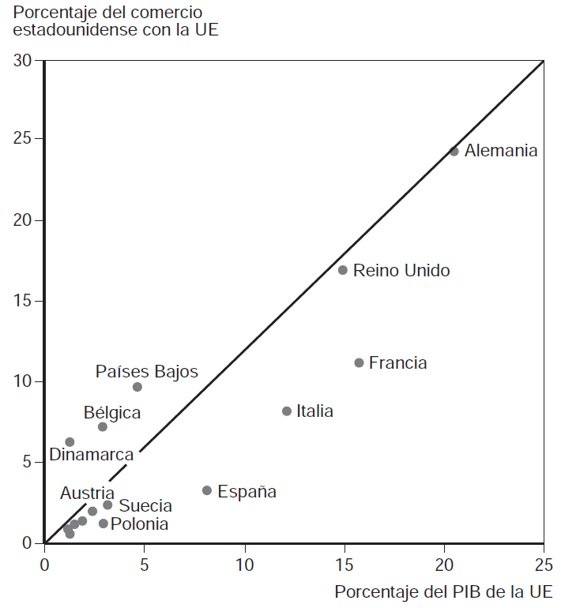

## Obstáculos al comercio

- El rol de la distancia $\longrightarrow$ Canadá y Méjico **comercian mucho más** con EEUU que lo que lo hacen economías de similar tamaño en la UE
  - mayoría de modelos estimados encuentran que un aumento de 1% en la distancia entre 2 (dos) países disminuye el comercio entre un 0.7 y 1%
- Pero además hay otro elemento $\longrightarrow$ EEUU, Canadá y Méjico **forman parte de un acuerdo comercial**, conocido como NAFTA –implica que no hay aranceles (salvoe excepciones) para el comercio entre esos países

## Obstáculos al comercio (cont.)

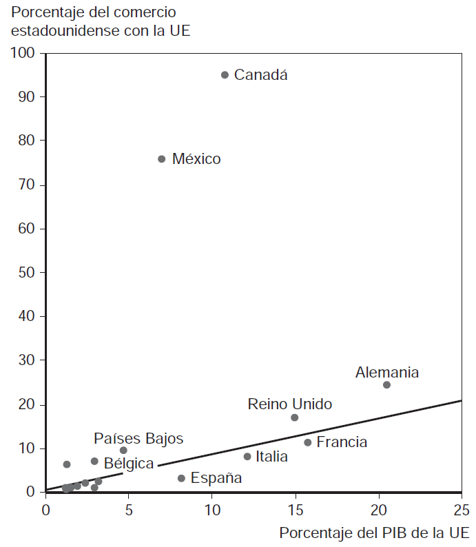

# Política comercial

## Política comercial

- Aún con todo lo dicho en relación al tamaño de las economías, la distancia (geografía) y los acuerdos comerciales, existen desde siempre incentivos a restringir el comercio internacional en oposición al nacional
  - Existencia de otro tipo de barreras formales
  - Crisis económicas
  - Razones de ideología política
- En otras palabras, una gran mayoría de países aún implementan y con bastante frecuencia **política comercial**

## Política comercial (cont.)

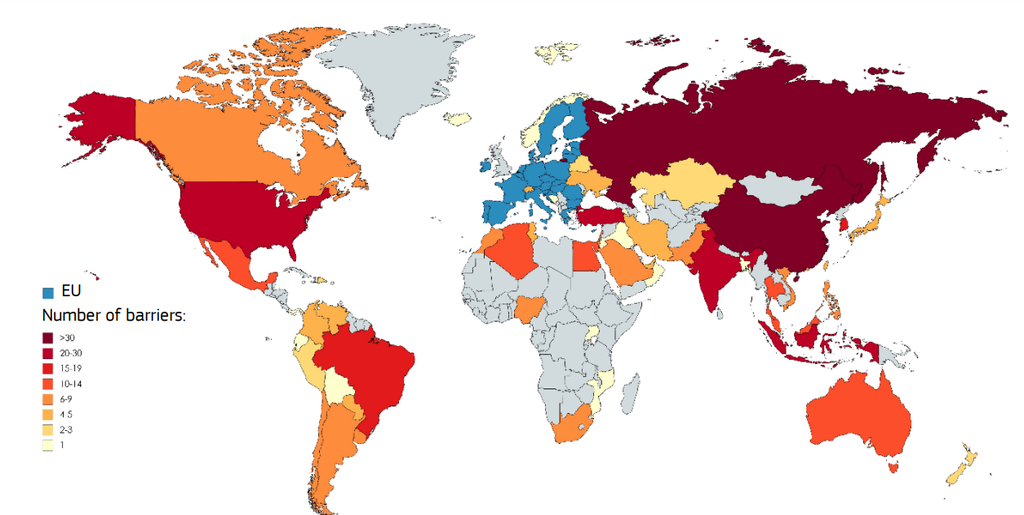

## Política comercial (cont.)

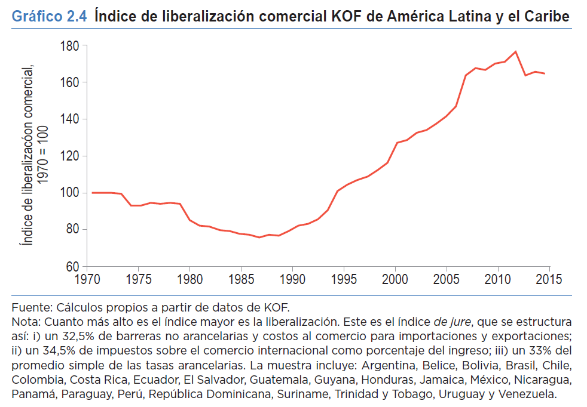

## Política comercial (cont.)

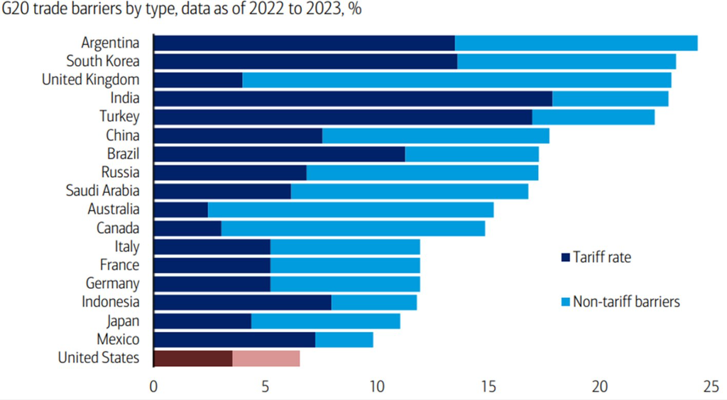

## Política comercial (cont.)

- La política comercial tiene (y han sido ampliamente estudiados) efectos microeconómicos y macroeconómicos pero también políticos
- Existen también simples intuiciones y evidencias anecdóticas que permiten ver cierta correlación entre países con política comercial restrictiva y sus niveles de poderío económico y/o otros indicadores de desarrollo
  - proteccionismo y pobreza por ejemplo…

## Política comercial (cont.)

[figure not shown]

Arancel promedio ponderado

[figure not shown]

Pobreza infantil

## Política comercial (cont.)

- Otras evidencias reflejan el hecho de que aún a pesar de la cercanía geográfica, las fronteras político-administrativas tienen un efecto negativo sobre el comercio
- Aplicación $\longrightarrow$ las provincias canadienses comercian significativamente más entre sí que con los estados de EEUU
  - En todos los casos, el comercio entre la Columbia Británica y una provincia canadiense es mucho mayor al que existe entre aquella y un estado equidistante de EEUU

## Política comercial (cont.)

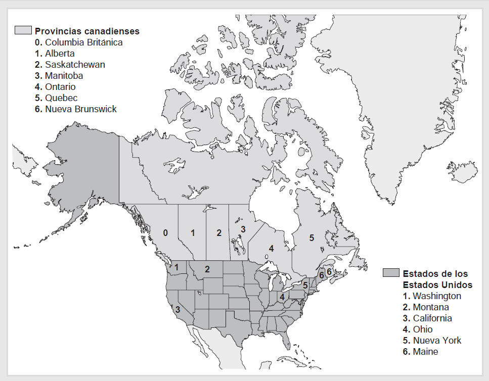

## Política comercial (cont.)

| **Pcia (Canadá)** | **Comercio (%)** | **Comercio (%)** | **Estado (EEUU)** |
| --- | --- | --- | --- |
| Alberta | 6.9 | 2.6 | Washington |
| Saskatchewan | 2.4 | 1.0 | Montana |
| Manitoba | 2.0 | 0.3 | California |
| Ontario | 1.9 | 0.2 | Ohio |
| Quebec | 1.4 | 0.1 | Nueva York |
| N. Brunswick | 2.3 | 0.2 | Maine |

Tabla 1: Comercio de estados sub-nacionales con la Columbia Británica

## Política comercial (cont.)

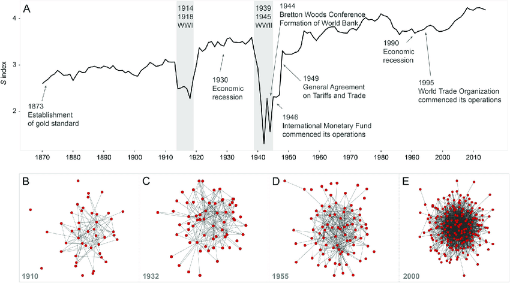

Evolución de la estructura de la red de comercio global. Fuente: Correlates of War Project Data Set